# Divides in Romanian Politics: A Referendum for the Traditional Family

Two prime-ministers forced out by their own party in the past year and a half, endless corruption scandals, and long-lasting demonstrations against and recently also one in support of the government - one would think there’s no room for more controversy in Romanian politics. A referendum about the so-called ‘traditional family’, however, begs to differ. What drives public attention in this issue? Web data mining provides more insights.

Nadina Iacob n.iacob@mpp.hertie-school.org Seminar: Web Data Collection and Social Media Mining Instructor: Simon Munzert Hertie School of Governance Word count: 1000 words

15 June 2018

On 23 May 2016, three million signatures were handed over to the Romanian Senate, marking the official beginning of a heated debate about what constitutes a family in Romania. The signatures were gathered in order to initiate a legislative procedure to amend the definition of the family in the Romanian Constitution as follows: “the family is based on the freely consented marriage of a man and a woman”, with “a man and a woman” replacing “spouses” in the current form of art. 48 of the constitution.

Fast forward to June 2018: A national referendum will be held to decide whether the constitution will be changed, though it is still unclear when exactly. While a number of dates have been brought up, one thing is certain: the way the political scene is divided on this topic, albeit perhaps surprising from an outsider’s perspective, is, in fact, a good reflection of Romanian politics.

### **For and against the “traditional family” referendum**

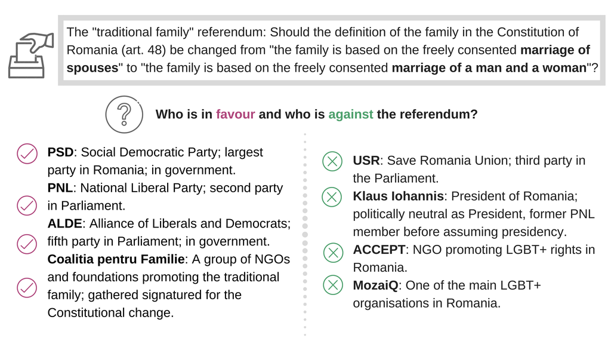

Stretching now for over two years, the “traditional family” debate is bound to have elicited fluctuating public attention, as different actors add in their views and the issue gains or loses momentum. In the age of Big Data, mapping this evolution granularly and almost in real time is just a google away. Given the simplicity of this method, it’s worth exploring whether the insights derived are actually meaningful.

As undoubtedly the most comprehensive search engine database readily available, Google Trends compiles individual searches into timely updates on interest in particular topics. Particularly with regards to issue salience, Google search data [performs relatively well in a number of situations](https://www.tandfonline.com/doi/abs/10.1080/17457289.2013.846346) when compared to more traditional data sources.

One of the most difficult tasks is to boil down numerous combinations of searches to only a couple that are deemed most representative for the debate. And perhaps herein also lies the main weakness of the method. With this note of caution in mind, in order to track the evolution of interest in the “traditional family” debate, three search terms have been selected (in Romanian), motivated by their occurrences in public discourse: “referendum familie” (EN: “referendum family”), “familia tradițională” (EN: “traditional family”), “Coaliția pentru familie” (EN: “Coalition for family”). While Romanian contains special characters, they are rarely used in informal interactions online, so they were disregarded in the search. The evolution of Google searches, as a proxy for public attention, is tracked on a relative scale (0% to 100%) from the moment the 3 million signatures were brought to the Senate, in May 2016, up to May 2018.

### **The “traditional family” referendum as reflected on Google Trends**

*Interest aggregated weekly (dates denote the beginning of the week). Hover over “!” for more details.*

[interactive chart not shown]

Google Trends shows clear reactions to the main developments, especially since, in this case, results are aggregated weekly. In a sense, this is intuitive: statements of key political figures or NGOs attract the attention and determine surges in interest in the topic and corresponding Internet searches. Furthermore, there appears to be a transition in the focus of the debate: while throughout 2016 and the first half of 2017 the debate seemed to revolve around Coaliția pentru Familie, the main stakeholder behind the push for a referendum, as dates for a referendum began to be speculated about, the “referendum familie” search term became more prominent.

The different announcements about a potential date for the referendum (especially from mid-2017 onwards) have given rise to spikes in public attention, even though no final decision on the matter is in sight. Beyond this, prominent events, like Pride Bucharest week, have undoubtedly contributed to surges in interest, drawing the attention of the general public.

While public attention in the overall issue may be captured by Google Trends, disentangling the support garnered by those for and those against is rather problematic. Not even in a social media sphere prominent in politics like Twitter is it easy to draw conclusions about [public opinion](http://journals.sagepub.com/doi/abs/10.1177/0894439316631043) by analysing aggregate data. For this, surveys remain indispensible. An April 2018 survey revealed that more than three quarters of the Romanian voting-eligible population are in favour of the proposed constitutional change. Should these numbers hold until the day of the referendum, the vote would not even be a close call. However, one must not forget that in a country where low electoral turnout is the norm ([39,49%](http://prezenta.bec.ro/) at the 2016 parliamentary elections), mobilisation in either camp would be decisive. Whether the political statements that spark interest in the issue also give rise to outrage or support could thus be the impetus behind passing or rejecting the change.

Meanwhile, the European Court of Justice has inadvertently introduced another element into the debate. A recent ruling (C-673/16 of 5 June 2018) states that all EU Member States must recognise the residency rights of same sex spouses of EU citizens, as part of the freedom of movement. Perhaps even more interesting is the fact that this decision is the result of a case brought forward by Adrian Coman, a Romanian citizen, and his husband, Robert Clabourn Hamilton, a US citizen. The ruling in itself has no impact on the legality of same-sex marriage in Romania, but it does bring another voice into the debate.